# Calibration Demo

This script tries to reproduce the model calibration for 3 timeseries.

#### A. Load subset of data for the demo

#### B. Define the models

The models are defined as in Zani et al. 2020. For this demo, only the TPM, TPDM and PIA+ models are considered.

#### C. Example 1. Timeseries: 1_Fagus_sylvatica

1. Select data for the timeseries
2. Estimate model parameters and predictions
3. Plot observed versus predicted autumn senescence dates for the timeseries.
1. The predictions are read from the ModelAnalysis_1_Predicted_DoYoff_subset.csv file provided by Zani et al. in Zenodo. These predictions are calculated using the function estimate_phenology from the phenor package.

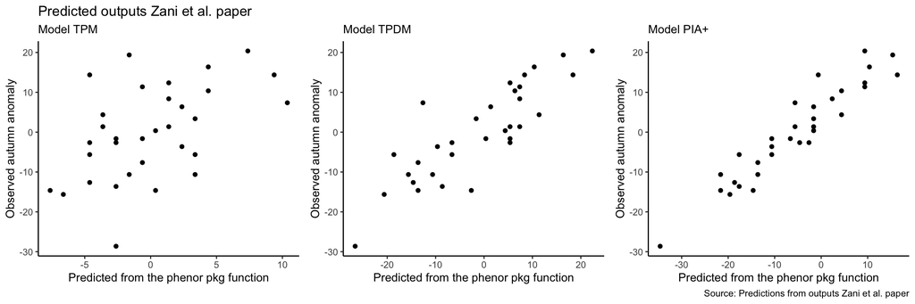

2. The predictions are the resulted from a timeseries calibration saved in file DoYoff_Preds.df_1_Fagus_sylvatica.RData. These predictions are calculated using the function estimate_phenology from the phenor package.

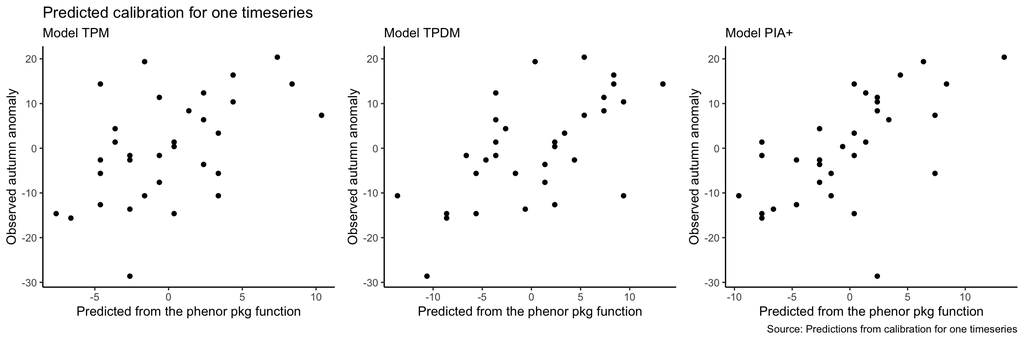

3. These figures plot predictions provided by Zani et al. in Zenodo vs. predictions from calibration using the phenor pck functions.

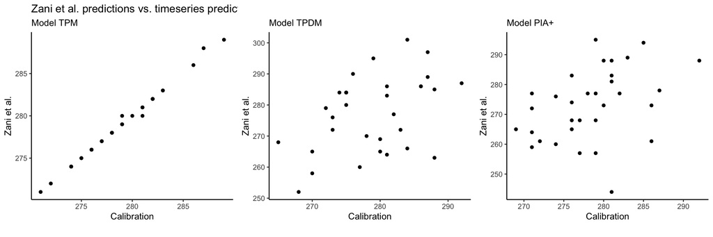

### C. Example 2. Timeseries: 1_Quercus_robur

1. Select data for the timeseries
2. Estimate model parameters and predictions
3. Plot observed versus predicted autumn senescence dates for the timeseries.
1. The predictions are read from the ModelAnalysis_1_Predicted_DoYoff_subset.csv file provided by Zani et al. in Zenodo. These predictions are calculated using the function estimate_phenology from the phenor package.

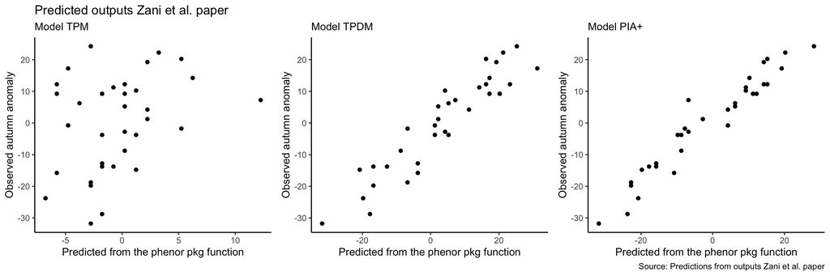

2. The predictions are the resulted from a timeseries calibration saved in file DoYoff_Preds.df_1_Quercus_robur.RData These predictions are calculated using the function estimate_phenology from the phenor package.

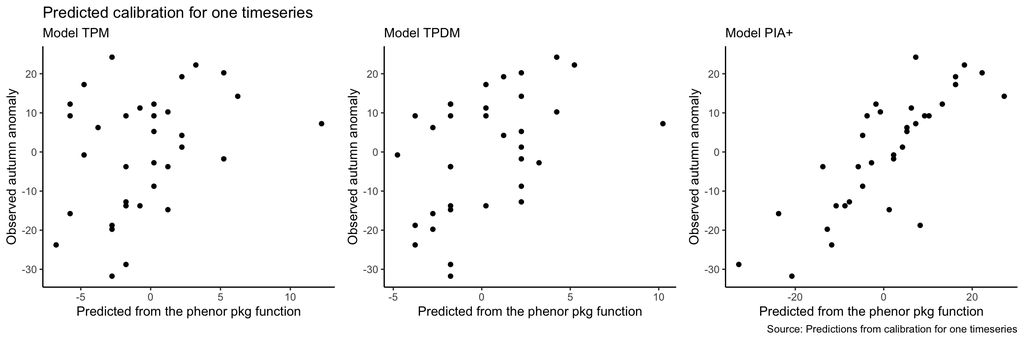

3. These figures plot predictions provided by Zani et al. in Zenodo vs. predictions from calibration using the phenor pck functions.

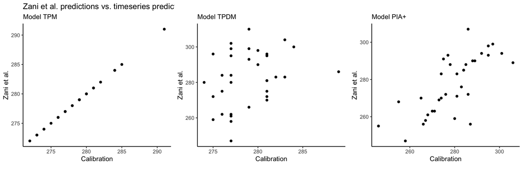

### C. Example 3. Timeseries: 1002_Aesculus_hippocastanum

1. Select data for the timeseries
2. Estimate model parameters and predictions
3. Plot observed versus predicted autumn senescence dates for the timeseries.
1. The predictions are read from the ModelAnalysis_1_Predicted_DoYoff_subset.csv file provided by Zani et al. in Zenodo. These predictions are calculated using the function estimate_phenology from the phenor package.

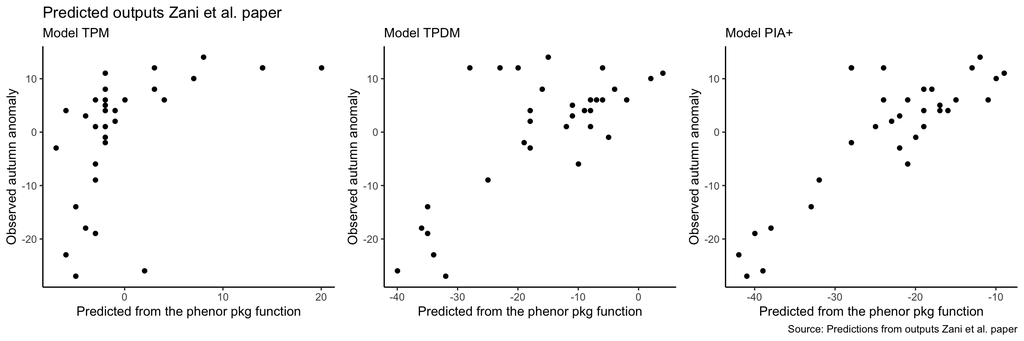

2. The predictions are the resulted from a timeseries calibration saved in file DoYoff_Preds.df_1002_Aesculus_hippocastanum.RData These predictions are calculated using the function estimate_phenology from the phenor package.

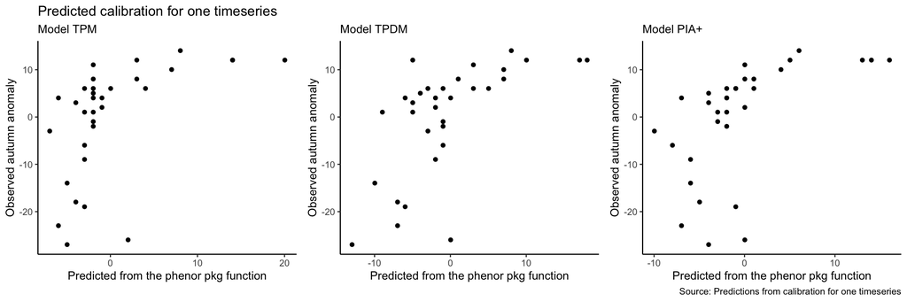

3. These figures plot predictions provided by Zani et al. in Zenodo vs. predictions from calibration using the phenor pck functions.

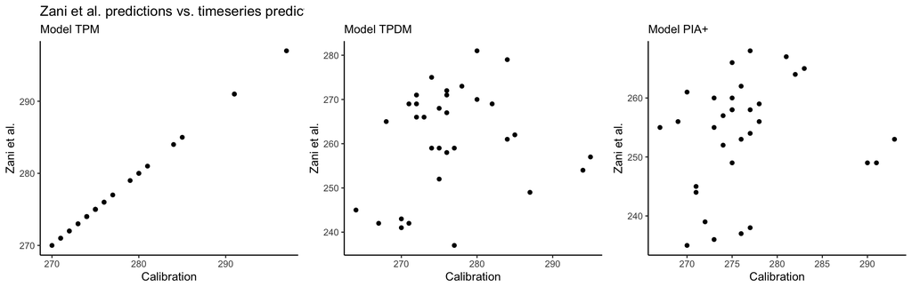